# Example Solution: Predicting House Prices

## Loading the Data

```python
import findspark
findspark.init()
import pyspark
```

```python
data_dir = "../.assets/data/house/"
```

```python
!ls {data_dir}
```

```
data_description.txt prices.csv
```

After creating a `SparkSession`, we read the contents of the .csv file into a DataFrame.

```python
spark = pyspark.sql.SparkSession \
    .builder \
    .appName("HousePricePredictor") \
    .getOrCreate()
```

```python
data = spark.read \
    .format("csv") \
    .option("header", "true") \
    .load(f"{data_dir}/prices.csv")
```

Defining a schema for this large dataframe beforehand is a daunting task, so we leave the types a the default (string) and cast later as needed. We know however that the prices should be floating point numbers:

```python
data = data.withColumn("SalePrice", data["SalePrice"].cast("DOUBLE"))
```

## Example Solution 1: A Simple First Model

This is a minimalistic model to get us started. We use a bit of domain knowledge to select a couple of promising features that are already in a format which the ML algorithm can process.

```python
discrete_features = [
                "OverallQual",
                "OverallCond",
                "YearBuilt",
                ]

continuous_features = [
                "LotArea",
                "GrLivArea",
                "PoolArea"
                ]
```

```python
for col_name in discrete_features:
    data = data.withColumn(col_name, data[col_name].cast("INT"))

for col_name in continuous_features:
    data = data.withColumn(col_name, data[col_name].cast("DOUBLE"))
```

```python
feature_cols = discrete_features + continuous_features
```

```python
from pyspark.ml.feature import VectorAssembler

assemble_features = VectorAssembler(inputCols=feature_cols,
                                    outputCol="features")
```

```python
from pyspark.ml.regression import DecisionTreeRegressor

regression = DecisionTreeRegressor(featuresCol="features")
```

```python
from pyspark.ml import Pipeline

pipeline = Pipeline(stages=[assemble_features, regression])
```

## Evaluation

Here we evaluate the performance of the regression model. A better model produces smaller errors in the predicted price. The two error metrics we use are **Root-Mean-Squared-Error (RMSE)** and **Mean Average Error (MAE)** between the predicted value and the observed sales price. In order to get robust scores with less random fluctuation, we apply **cross-validation**.

```python
import pandas
from pyspark.ml.evaluation import RegressionEvaluator
from pyspark.ml.tuning import CrossValidator, ParamGridBuilder
```

```python
rmse = CrossValidator(estimator=pipeline,
                    evaluator=RegressionEvaluator(metricName="rmse", labelCol="label", predictionCol="prediction"),
                    estimatorParamMaps=ParamGridBuilder().build(),
                    numFolds=4) \
                    .fit(data.withColumnRenamed("SalePrice", "label")) \
                    .avgMetrics[0]

mae = CrossValidator(estimator=pipeline,
                    evaluator=RegressionEvaluator(metricName="mae", labelCol="label", predictionCol="prediction"),
                    estimatorParamMaps=ParamGridBuilder().build(),
                    numFolds=4) \
                    .fit(data.withColumnRenamed("SalePrice", "label")) \
                    .avgMetrics[0]
```

### Result

```python
import datetime
team_name = "Minimalists"
print("\t".join(["time", "team", "RMSE", "MAE"]))
print("\t".join([datetime.datetime.now().strftime("%Y-%m-%d %H:%M:%S"), team_name, "{0:.4f}".format(rmse), "{0:.4f}".format(mae)]))
```

```
time	team	RMSE	MAE
2019-05-07 12:59:04	Minimalists	44494.8823	27994.6357
```

## Diagnostics

In order to get a better understanding of the error made by the model, plot the distribution of prices, predicted prices, and errors. This can provide useful feedback for model improvement.

```python
predicted = pipeline.fit(data.withColumnRenamed("SalePrice", "label")).transform(data)
predicted[["SalePrice", "prediction"]].show()
```

```
+---------+------------------+
|SalePrice|        prediction|
+---------+------------------+
| 208500.0|193479.33974358975|
| 181500.0|144221.19523809524|
| 223500.0|193479.33974358975|
| 140000.0|       156364.0625|
| 250000.0| 310571.4827586207|
| 143000.0|144221.19523809524|
| 307000.0| 260908.8275862069|
| 200000.0|224502.11111111112|
| 129900.0|       156364.0625|
| 118000.0|111174.13333333333|
| 129500.0| 123079.7052631579|
| 345000.0|          441710.7|
| 144000.0| 123079.7052631579|
| 279500.0|193479.33974358975|
| 157000.0|144221.19523809524|
| 132000.0|       156364.0625|
| 149000.0| 123079.7052631579|
|  90000.0|144221.19523809524|
| 159000.0|144221.19523809524|
| 139000.0|144221.19523809524|
+---------+------------------+
only showing top 20 rows
```

```python
predicted_pd = predicted[["SalePrice", "prediction"]].toPandas()
```

```python
import seaborn
seaborn.set_style("whitegrid")
```

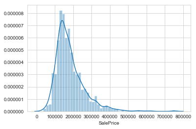

```python
seaborn.distplot(predicted_pd["SalePrice"])
```

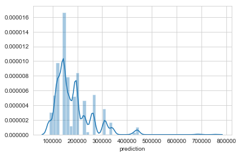

```python
seaborn.distplot(predicted_pd["prediction"])
```

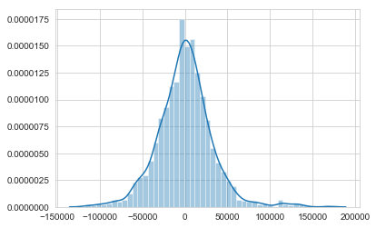

```python
seaborn.distplot(predicted_pd["SalePrice"] - predicted_pd["prediction"])
```

## Example Solution 2: Philipp's Model

Data scientist Philipp also gave house price prediction a try. Experienced in machine learning and predictive modeling, but new to Spark, he spent a few hours and built a more elaborate model. He also described his workflow for us. Let's follow the steps he took - particularly his feature engineering - and see how his model is doing compared to the minimalistic one.

```python
from pyspark.ml import Transformer, Estimator, Pipeline, PipelineModel
from pyspark.ml.feature import OneHotEncoderEstimator, StringIndexer
```

```python
numeric_features = ['OverallQual', 'OverallCond', 'YearBuilt', 'BsmtFinSF1', 'BsmtUnfSF', 'TotalBsmtSF',
                    '1stFlrSF', '2ndFlrSF', 'LowQualFinSF', 'GrLivArea', 'BsmtFullBath', 'BsmtHalfBath',
                    'FullBath', 'HalfBath', 'TotRmsAbvGrd', 'Fireplaces', 'GarageCars', 'GarageArea',
                    'WoodDeckSF', 'OpenPorchSF', 'EnclosedPorch', '3SsnPorch', 'ScreenPorch',
                    'PoolArea']
rating_features = ['ExterQual', 'ExterCond', 'BsmtQual', 'BsmtCond', 'BsmtExposure', 'BsmtFinType1',
                   'HeatingQC', 'CentralAir', 'KitchenQual', 'Functional', 'FireplaceQu', 'GarageFinish',
                   'GarageQual', 'GarageCond', 'PavedDrive', 'PoolQC', 'Fence']
categorical_features = ['SaleCondition']

features = numeric_features+rating_features+categorical_features

target = ['SalePrice']
```

> Unfortunately, we cannot simply use show to display the features in an easy way. We have to split the visualization.

```python
data[features[:10]].show()
```

```
+-----------+-----------+---------+----------+---------+-----------+--------+--------+------------+---------+
|OverallQual|OverallCond|YearBuilt|BsmtFinSF1|BsmtUnfSF|TotalBsmtSF|1stFlrSF|2ndFlrSF|LowQualFinSF|GrLivArea|
+-----------+-----------+---------+----------+---------+-----------+--------+--------+------------+---------+
|          7|          5|     2003|       706|      150|        856|     856|     854|           0|   1710.0|
|          6|          8|     1976|       978|      284|       1262|    1262|       0|           0|   1262.0|
|          7|          5|     2001|       486|      434|        920|     920|     866|           0|   1786.0|
|          7|          5|     1915|       216|      540|        756|     961|     756|           0|   1717.0|
|          8|          5|     2000|       655|      490|       1145|    1145|    1053|           0|   2198.0|
|          5|          5|     1993|       732|       64|        796|     796|     566|           0|   1362.0|
|          8|          5|     2004|      1369|      317|       1686|    1694|       0|           0|   1694.0|
|          7|          6|     1973|       859|      216|       1107|    1107|     983|           0|   2090.0|
|          7|          5|     1931|         0|      952|        952|    1022|     752|           0|   1774.0|
|          5|          6|     1939|       851|      140|        991|    1077|       0|           0|   1077.0|
|          5|          5|     1965|       906|      134|       1040|    1040|       0|           0|   1040.0|
|          9|          5|     2005|       998|      177|       1175|    1182|    1142|           0|   2324.0|
|          5|          6|     1962|       737|      175|        912|     912|       0|           0|    912.0|
|          7|          5|     2006|         0|     1494|       1494|    1494|       0|           0|   1494.0|
|          6|          5|     1960|       733|      520|       1253|    1253|       0|           0|   1253.0|
|          7|          8|     1929|         0|      832|        832|     854|       0|           0|    854.0|
|          6|          7|     1970|       578|      426|       1004|    1004|       0|           0|   1004.0|
|          4|          5|     1967|         0|        0|          0|    1296|       0|           0|   1296.0|
|          5|          5|     2004|       646|      468|       1114|    1114|       0|           0|   1114.0|
|          5|          6|     1958|       504|      525|       1029|    1339|       0|           0|   1339.0|
+-----------+-----------+---------+----------+---------+-----------+--------+--------+------------+---------+
only showing top 20 rows
```

```python
data[features[10:20]].show()
```

```
+------------+------------+--------+--------+------------+----------+----------+----------+----------+-----------+
|BsmtFullBath|BsmtHalfBath|FullBath|HalfBath|TotRmsAbvGrd|Fireplaces|GarageCars|GarageArea|WoodDeckSF|OpenPorchSF|
+------------+------------+--------+--------+------------+----------+----------+----------+----------+-----------+
|           1|           0|       2|       1|           8|         0|         2|       548|         0|         61|
|           0|           1|       2|       0|           6|         1|         2|       460|       298|          0|
|           1|           0|       2|       1|           6|         1|         2|       608|         0|         42|
|           1|           0|       1|       0|           7|         1|         3|       642|         0|         35|
|           1|           0|       2|       1|           9|         1|         3|       836|       192|         84|
|           1|           0|       1|       1|           5|         0|         2|       480|        40|         30|
|           1|           0|       2|       0|           7|         1|         2|       636|       255|         57|
|           1|           0|       2|       1|           7|         2|         2|       484|       235|        204|
|           0|           0|       2|       0|           8|         2|         2|       468|        90|          0|
|           1|           0|       1|       0|           5|         2|         1|       205|         0|          4|
|           1|           0|       1|       0|           5|         0|         1|       384|         0|          0|
|           1|           0|       3|       0|          11|         2|         3|       736|       147|         21|
|           1|           0|       1|       0|           4|         0|         1|       352|       140|          0|
|           0|           0|       2|       0|           7|         1|         3|       840|       160|         33|
|           1|           0|       1|       1|           5|         1|         1|       352|         0|        213|
|           0|           0|       1|       0|           5|         0|         2|       576|        48|        112|
|           1|           0|       1|       0|           5|         1|         2|       480|         0|          0|
|           0|           0|       2|       0|           6|         0|         2|       516|         0|          0|
|           1|           0|       1|       1|           6|         0|         2|       576|         0|        102|
|           0|           0|       1|       0|           6|         0|         1|       294|         0|          0|
+------------+------------+--------+--------+------------+----------+----------+----------+----------+-----------+
only showing top 20 rows
```

```python
data[features[20:30]].show()
```

```
+-------------+---------+-----------+--------+---------+---------+--------+--------+------------+------------+
|EnclosedPorch|3SsnPorch|ScreenPorch|PoolArea|ExterQual|ExterCond|BsmtQual|BsmtCond|BsmtExposure|BsmtFinType1|
+-------------+---------+-----------+--------+---------+---------+--------+--------+------------+------------+
|            0|        0|          0|     0.0|       Gd|       TA|      Gd|      TA|          No|         GLQ|
|            0|        0|          0|     0.0|       TA|       TA|      Gd|      TA|          Gd|         ALQ|
|            0|        0|          0|     0.0|       Gd|       TA|      Gd|      TA|          Mn|         GLQ|
|          272|        0|          0|     0.0|       TA|       TA|      TA|      Gd|          No|         ALQ|
|            0|        0|          0|     0.0|       Gd|       TA|      Gd|      TA|          Av|         GLQ|
|            0|      320|          0|     0.0|       TA|       TA|      Gd|      TA|          No|         GLQ|
|            0|        0|          0|     0.0|       Gd|       TA|      Ex|      TA|          Av|         GLQ|
|          228|        0|          0|     0.0|       TA|       TA|      Gd|      TA|          Mn|         ALQ|
|          205|        0|          0|     0.0|       TA|       TA|      TA|      TA|          No|         Unf|
|            0|        0|          0|     0.0|       TA|       TA|      TA|      TA|          No|         GLQ|
|            0|        0|          0|     0.0|       TA|       TA|      TA|      TA|          No|         Rec|
|            0|        0|          0|     0.0|       Ex|       TA|      Ex|      TA|          No|         GLQ|
|            0|        0|        176|     0.0|       TA|       TA|      TA|      TA|          No|         ALQ|
|            0|        0|          0|     0.0|       Gd|       TA|      Gd|      TA|          Av|         Unf|
|          176|        0|          0|     0.0|       TA|       TA|      TA|      TA|          No|         BLQ|
|            0|        0|          0|     0.0|       TA|       TA|      TA|      TA|          No|         Unf|
|            0|        0|          0|     0.0|       TA|       TA|      TA|      TA|          No|         ALQ|
|            0|        0|          0|     0.0|       TA|       TA|      NA|      NA|          NA|          NA|
|            0|        0|          0|     0.0|       TA|       TA|      TA|      TA|          No|         GLQ|
|            0|        0|          0|     0.0|       TA|       TA|      TA|      TA|          No|         LwQ|
+-------------+---------+-----------+--------+---------+---------+--------+--------+------------+------------+
only showing top 20 rows
```

```python
data[features[30:40]].show()
```

```
+---------+----------+-----------+----------+-----------+------------+----------+----------+----------+------+
|HeatingQC|CentralAir|KitchenQual|Functional|FireplaceQu|GarageFinish|GarageQual|GarageCond|PavedDrive|PoolQC|
+---------+----------+-----------+----------+-----------+------------+----------+----------+----------+------+
|       Ex|         Y|         Gd|       Typ|         NA|         RFn|        TA|        TA|         Y|    NA|
|       Ex|         Y|         TA|       Typ|         TA|         RFn|        TA|        TA|         Y|    NA|
|       Ex|         Y|         Gd|       Typ|         TA|         RFn|        TA|        TA|         Y|    NA|
|       Gd|         Y|         Gd|       Typ|         Gd|         Unf|        TA|        TA|         Y|    NA|
|       Ex|         Y|         Gd|       Typ|         TA|         RFn|        TA|        TA|         Y|    NA|
|       Ex|         Y|         TA|       Typ|         NA|         Unf|        TA|        TA|         Y|    NA|
|       Ex|         Y|         Gd|       Typ|         Gd|         RFn|        TA|        TA|         Y|    NA|
|       Ex|         Y|         TA|       Typ|         TA|         RFn|        TA|        TA|         Y|    NA|
|       Gd|         Y|         TA|      Min1|         TA|         Unf|        Fa|        TA|         Y|    NA|
|       Ex|         Y|         TA|       Typ|         TA|         RFn|        Gd|        TA|         Y|    NA|
|       Ex|         Y|         TA|       Typ|         NA|         Unf|        TA|        TA|         Y|    NA|
|       Ex|         Y|         Ex|       Typ|         Gd|         Fin|        TA|        TA|         Y|    NA|
|       TA|         Y|         TA|       Typ|         NA|         Unf|        TA|        TA|         Y|    NA|
|       Ex|         Y|         Gd|       Typ|         Gd|         RFn|        TA|        TA|         Y|    NA|
|       TA|         Y|         TA|       Typ|         Fa|         RFn|        TA|        TA|         Y|    NA|
|       Ex|         Y|         TA|       Typ|         NA|         Unf|        TA|        TA|         Y|    NA|
|       Ex|         Y|         TA|       Typ|         TA|         Fin|        TA|        TA|         Y|    NA|
|       TA|         Y|         TA|       Typ|         NA|         Unf|        TA|        TA|         Y|    NA|
|       Ex|         Y|         Gd|       Typ|         NA|         Unf|        TA|        TA|         Y|    NA|
|       TA|         Y|         TA|      Min1|         NA|         Unf|        TA|        TA|         Y|    NA|
+---------+----------+-----------+----------+-----------+------------+----------+----------+----------+------+
only showing top 20 rows
```

```python
data[features[40:]].show()
```

```
+-----+-------------+
|Fence|SaleCondition|
+-----+-------------+
|   NA|       Normal|
|   NA|       Normal|
|   NA|       Normal|
|   NA|      Abnorml|
|   NA|       Normal|
|MnPrv|       Normal|
|   NA|       Normal|
|   NA|       Normal|
|   NA|      Abnorml|
|   NA|       Normal|
|   NA|       Normal|
|   NA|      Partial|
|   NA|       Normal|
|   NA|      Partial|
| GdWo|       Normal|
|GdPrv|       Normal|
|   NA|       Normal|
|   NA|       Normal|
|   NA|       Normal|
|MnPrv|      Abnorml|
+-----+-------------+
only showing top 20 rows
```

> So let's build a simple transformer which shortens our data to only the features we specified here.

```python
class ColumnDropper(Transformer):
    """
    Reduce data to only a subset of columns
    """

    # lazy workaround - a transformer needs to have these attributes
    # TODO: replace if needed
    _defaultParamMap = dict()
    _paramMap = dict()
    _params = dict()
    uid = 0

    def __init__(self, cols=None):
        self.cols = cols


    def _transform(self, data):
        dataAfterDrop = data[self.cols]
        return dataAfterDrop

    def __repr__(self):
        """ Show a proper string representation when printing the pipeline stage"""
        return str(type(self))
```

```python
select_pipeline = Pipeline(stages=[ColumnDropper(cols=features+target)])
data_short = select_pipeline.fit(data).transform(data)
```

**Looking for Missing Values**

> Let's use the code from the previous example to check for missing values.

```python
for col in data_short.columns:
    print(col, " : ", data_short.filter(f"{col} is NULL").count())
```

```
OverallQual  :  0
OverallCond  :  0
YearBuilt  :  0
BsmtFinSF1  :  0
BsmtUnfSF  :  0
TotalBsmtSF  :  0
1stFlrSF  :  0
2ndFlrSF  :  0
LowQualFinSF  :  0
GrLivArea  :  0
BsmtFullBath  :  0
BsmtHalfBath  :  0
FullBath  :  0
HalfBath  :  0
TotRmsAbvGrd  :  0
Fireplaces  :  0
GarageCars  :  0
GarageArea  :  0
WoodDeckSF  :  0
OpenPorchSF  :  0
EnclosedPorch  :  0
3SsnPorch  :  0
ScreenPorch  :  0
PoolArea  :  0
ExterQual  :  0
ExterCond  :  0
BsmtQual  :  0
BsmtCond  :  0
BsmtExposure  :  0
BsmtFinType1  :  0
HeatingQC  :  0
CentralAir  :  0
KitchenQual  :  0
Functional  :  0
FireplaceQu  :  0
GarageFinish  :  0
GarageQual  :  0
GarageCond  :  0
PavedDrive  :  0
PoolQC  :  0
Fence  :  0
SaleCondition  :  0
SalePrice  :  0
```

> No missing values!

**Converting the attribute data types**

> Now I can start converting the data types of the attributes. For numeric features this is simple, it gets hard however when I try convert a rating-type attribute to numeric values. Unfortunately, the data does not follow a uniform convention on how to rate things. For every type of rating, I have to build a translation table... This could be automated using the documentation file, but in this case (because I do not expect to do this again) I choose the manual approach. I create a table index to specify which column uses which table, and then I create the translation tables itself, where every string value is given a numeric value.

This is a nice example for how much work could be saved by already thinking about later uses of the data when collecting it - a uniform rating scheme would make things simpler. Well, as data scientist we are used to spending most of our time cleaning data, so let's get to it.

```python
table_index = {'ExterQual' : 0,
               'ExterCond' : 0,
               'BsmtQual' : 0,
               'BsmtCond' : 0,
               'BsmtExposure' : 1,
               'BsmtFinType1' : 2,
               'HeatingQC' : 0,
               'CentralAir' : 3,
               'KitchenQual' : 0,
               'Functional' : 4,
               'FireplaceQu' : 0,
               'GarageFinish' : 5,
               'GarageQual' : 0,
               'GarageCond' : 0,
               'PavedDrive' : 6,
               'PoolQC' : 7,
               'Fence' : 8}


translation_tables = []
translation_tables.append({'Ex' : '0', # I have to use strings, because df.na.replace does
                       'Gd' : '1', # not support mixed type replacing
                       'TA' : '2',
                       'Fa' : '3',
                       'Po' : '4',
                       'NA' : '5'})

translation_tables.append({'Gd' : '0',
                       'Av' : '1',
                       'Mn' : '2',
                       'No' : '3',
                       'NA' : '4'})

translation_tables.append({'GLQ' : '0',
                       'ALQ' : '1',
                       'BLQ' : '2',
                       'Rec' : '3',
                       'LwQ' : '4',
                       'Unf' : '5',
                       'NA' : '6'})

translation_tables.append({'N' : '0',
                       'Y' : '1'})

translation_tables.append({'Typ' : '0',
                       'Min1' : '1',
                       'Min2' : '2',
                       'Mod' : '3',
                       'Maj1' : '4',
                       'Maj2' : '5',
                       'Sev' : '6',
                       'Sal' : '7'})

translation_tables.append({'Fin' : '0',
                       'RFn' : '1',
                       'Unf' : '2',
                       'NA' : '3'})

translation_tables.append({'Y' : '0',
                       'P' : '1',
                       'N' : '2'})

translation_tables.append({'Ex' : '0',
                       'Gd' : '1',
                       'TA' : '2',
                       'Fa' : '3',
                       'NA' : '4'})

translation_tables.append({'GdPrv' : '0',
                       'MnPrv' : '1',
                       'GdWo' : '2',
                       'MnWw' : '3',
                       'NA' : '4'})
```

```python
class TypeConverter(Transformer):
    """
    Converts set of columns to numeric types
    """

    # lazy workaround - a transformer needs to have these attributes
    # TODO: replace if needed
    _defaultParamMap = dict()
    _paramMap = dict()
    _params = dict()
    uid = 0

    def __init__(self, numeric_features=None, rating_features=None, table_index=None, translation_tables=None):
        self.numeric_features = numeric_features # List of all numeric columns
        self.rating_features = rating_features # List of all rating columns
        self.table_index = table_index # What translation table to use for what rating column
        self.translation_tables = translation_tables


    def _transform(self, data):
        for col in data.columns:
            if col in self.numeric_features:
                data = (data.withColumn(col, data[col].cast("double")))
            elif col in self.rating_features:
                trans_table_nr = self.table_index[col]
                data = data.na.replace(self.translation_tables[trans_table_nr], value=None, subset=col)
                data = (data.withColumn(col, data[col].cast("double")))
            #else:
                #print("Did not convert column " + col + " with transformer TypeConverter.")
        return data

    def __repr__(self):
        """ Show a proper string representation when printing the pipeline stage"""
        return str(type(self))
```

> All we need now is to convert the attribute SaleCondition with OneHotEncoding. We also drop the temporarily created column SaleCondition_index and the column SaleCondition and proceed only with the One-Hot encoded variant.

```python
stages = []
stages.append(StringIndexer(inputCol='SaleCondition',
                            outputCol='SaleCondition_index')) # One-Hot Encoding does not work with strings...
stages.append(OneHotEncoderEstimator(inputCols=['SaleCondition_index'],
                                     outputCols=['SaleCondition_onehot']))
stages.append(TypeConverter(numeric_features=numeric_features+target, rating_features=rating_features,
                                                  table_index=table_index, translation_tables=translation_tables))
features_new = features.copy()
features_new.remove('SaleCondition')
features_new.append('SaleCondition_onehot')
stages.append(ColumnDropper(cols=features_new+target))
preproc_pipeline = Pipeline(stages=stages)
```

```python
%time data_preproc = preproc_pipeline.fit(data_short).transform(data_short)
```

```
CPU times: user 101 ms, sys: 21.8 ms, total: 123 ms
Wall time: 874 ms
```

**Assembling all feature columns into one single columns and renaming the target column to label**

```python
class LabelRenamer(Transformer):
    """
    Drops rows with at least one not-a-number element
    """

    # lazy workaround - a transformer needs to have these attributes
    # TODO: replace if needed
    _defaultParamMap = dict()
    _paramMap = dict()
    _params = dict()
    uid = 0

    def __init__(self, col=None):
        self.col = col


    def _transform(self, data):
        dataRenamed = data.withColumnRenamed(self.col, 'label')
        return dataRenamed

    def __repr__(self):
        """ Show a proper string representation when printing the pipeline stage"""
        return str(type(self))
```

```python
from pyspark.ml.feature import VectorAssembler

stages = []
stages.append(LabelRenamer(col=target[0]))
stages.append(VectorAssembler(inputCols=features_new, outputCol='features'))
spark_needs_this_pipeline = Pipeline(stages=stages)
data_sparked = spark_needs_this_pipeline.fit(data_preproc).transform(data_preproc)
```

**Using regression to predict the target variable**

```python
from pyspark.ml.regression import RandomForestRegressor

model_pipeline = Pipeline(stages=[RandomForestRegressor(featuresCol = 'features', labelCol = 'label')])
data_model = model_pipeline.fit(data_sparked).transform(data_sparked)
```

**Joining all pipelines to a single pipeline**

```python
pipeline = Pipeline(stages=[select_pipeline, preproc_pipeline, spark_needs_this_pipeline, model_pipeline])
```

How does Philipp's model perform? We run our evaluation code. Compare the results to the minimal model above.

## Evaluation

Here we evaluate the performance of the regression model. A better model produces smaller errors in the predicted price. The two error metrics we use are **Root-Mean-Squared-Error (RMSE)** and **Mean Average Error (MAE)** between the predicted value and the observed sales price. In order to get robust scores with less random fluctuation, we apply **cross-validation**.

```python
import pandas
from pyspark.ml.evaluation import RegressionEvaluator
from pyspark.ml.tuning import CrossValidator, ParamGridBuilder
```

```python
rmse = CrossValidator(estimator=pipeline,
                    evaluator=RegressionEvaluator(metricName="rmse", labelCol="label", predictionCol="prediction"),
                    estimatorParamMaps=ParamGridBuilder().build(),
                    numFolds=4) \
                    .fit(data) \
                    .avgMetrics[0]

mae = CrossValidator(estimator=pipeline,
                    evaluator=RegressionEvaluator(metricName="mae", labelCol="label", predictionCol="prediction"),
                    estimatorParamMaps=ParamGridBuilder().build(),
                    numFolds=4) \
                    .fit(data) \
                    .avgMetrics[0]
```

### Result

```python
import datetime
team_name = "Philipp"
print("\t".join(["time", "team", "RMSE", "MAE"]))
print("\t".join([datetime.datetime.now().strftime("%Y-%m-%d %H:%M:%S"), team_name, "{0:.4f}".format(rmse), "{0:.4f}".format(mae)]))
```

```
time	team	RMSE	MAE
2019-05-07 12:59:42	Philipp	34261.4513	20701.8836
```

## Diagnostics

In order to get a better understanding of the error made by the model, plot the distribution of prices, predicted prices, and errors. This can provide useful feedback for model improvement.

```python
predicted = pipeline.fit(data).transform(data)
predicted[["label", "prediction"]].show()
```

```
+--------+------------------+
|   label|        prediction|
+--------+------------------+
|208500.0|201339.99659344248|
|181500.0|  165466.611515753|
|223500.0|209161.05763843266|
|140000.0| 182962.3491411451|
|250000.0|289901.05293882906|
|143000.0|135914.53146556733|
|307000.0|282515.73737244087|
|200000.0|205514.59559363537|
|129900.0|166770.94920916657|
|118000.0|137738.03779169262|
|129500.0|133042.82244470663|
|345000.0|371110.61684647197|
|144000.0|125212.64865548217|
|279500.0|228669.22550892868|
|157000.0|147849.21108792446|
|132000.0|137066.41784985887|
|149000.0|144076.77691766337|
| 90000.0|118518.41762575845|
|159000.0| 148888.5350189945|
|139000.0|133787.03579009656|
+--------+------------------+
only showing top 20 rows
```

```python
predicted_pd = predicted[["label", "prediction"]].toPandas()
```

```python
import seaborn
seaborn.set_style("whitegrid")
```

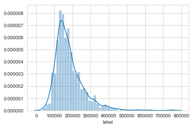

```python
seaborn.distplot(predicted_pd["label"])
```

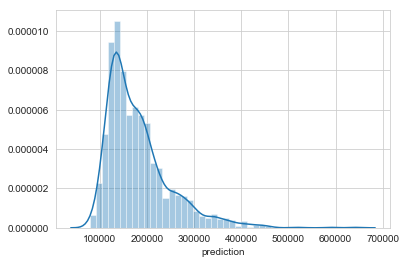

```python
seaborn.distplot(predicted_pd["prediction"])
```

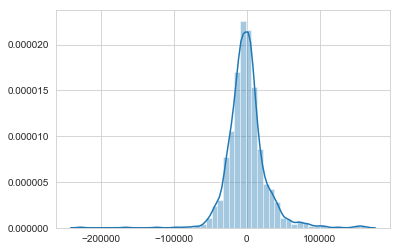

```python
seaborn.distplot(predicted_pd["label"] - predicted_pd["prediction"])
```

*This notebook is licensed under a [Creative Commons Attribution 4.0 International License (CC BY 4.0)](https://creativecommons.org/licenses/by/4.0/). Copyright © 2018 [Point 8 GmbH](https://point-8.de)*